# Giardia_riskdraft

Anika Larson

5/19/2016

To Do: Rewrite this for an exponential equation for Giardia, using new Giardia dose-response relationship data.

For this risk estimate, we will use mcmodel and evalmcmod from the [mc2d](https://cran.r-project.org/web/packages/mc2d/index.html) package.

```r
# Load packages.
library(mc2d)
library(data.table)
library(sfsmisc)
```

```r
library(graphics)
```

### Define variables

Set the number of simulations for the variability and uncertainty dimensions.

```r
nsv <- 401
nsu <- 108
ndvar(nsv)  # Variability
```

```
## [1] 401
```

```r
ndunc(nsu)   # Uncertainty
```

```
## [1] 108
```

The *mc2d* functions will set `nsv` to `ndvar()` and `nsu` to `ndunc()` by default. Alternatively, we could supply these values to the *mc2d* model functions when we call them.

Define the variables we will use to set the `seed` for random sampling and the number of `digits` for `print()` statements.

```r
seed <- 1
digits <- 5
```

Introducing the bootstrapped dose-response data, fread command and sampling from Brian:

```r
klist <- fread("output_rendtorff_giardia/klist.csv", sep = ',')
gdrk <- klist[sample(nrow(klist), nsu, replace = TRUE), list(x)] #sampling rows in the dose-response bootstrapped table equal to the number of simulations in the uncertainty dimension, aka NSU
```

Sampling from the Giardia Crabtree custom distribution estimates:

```r
cw.vlg <- fread("cwvl_estimates/giardia_estwol.csv", sep = ',')
cw.vl.samp <- sample(cw.vlg[,c(V1)], nsu, replace = TRUE)
```

```r
  #pfc_reduc set using the distribution
  gcfilt <- fread("cer_filts/CerFiltGiardia.csv", sep = ',')
  colnames(gcfilt) <- c("trial","logr")
  gcfilt$reduc <- (1 - (10^(-gcfilt$logr)))
  pfc_reduc2 <- gcfilt[sample(nrow(gcfilt), nsu, replace = TRUE), list(reduc)]
```

```r
  #Creating a distribution for hosing
  hose <- fread("exp_params/Hosing.csv", sep = ',')
  colnames(hose) <- c("trial","num", "mL")
  hose$hose_exp1 <- ((hose$num * hose$mL) / 7)
  hose_exp <- hose[sample(nrow(hose), nsu, replace = TRUE), list(hose_exp1)]
```

```r
  #Creating a distribution for showering
  shower <- fread("exp_params/Showers.csv", sep = ',')
  colnames(shower) <- c("trial","num", "mL")
  shower$shower_exp1 <- ((shower$num * shower$mL) / 7)
  shower_exp <- shower[sample(nrow(shower), nsu, replace = TRUE), list(shower_exp1)]
```

We will use this variable to explicitly set the seed with the various *mc2d* functions. Another approach would be to only set it through the model evaluation functions, or not at all. Since we want to do our best to provide the most reproducible results, we set the seed explicitly.

### Define exposure model

Within the mcmodel function, use mcstoc to define “mc nodes” for each component of the model.

For each stochastic variable, use the `mcstoc()` function to create a “mcnode”, supply a probability function, the node type as “V” for variability or “U” for uncertainty, and any additional parameters to be passed to the probability function.

For deterministic variables, create nodes with the `mcdata()` function using the “0” type.

We will model the deterministic factors as uniform probablity distributions.

The last statement makes an “mc” object using the mc function.

```r
# Define an exposure model for evaluation by evalmcmod().
expo.mod1 <- mcmodel({
  # Values from Example 6.18 from Quantitative Microbial Risk Assessment,
  # 2nd Edition by Charles N. Haas, Joan B. Rose, and Charles P. Gerba.
  # (Wiley, 2014), pp. 215-216. Other fictitious values are noted below.

   # Cistern water viral loading (viruses/L):
  cw.vl1 <- mcdata(cw.vl.samp, type = "U")
  cw.vl2 <- mcstoc(rempiricalD, type = "V", values = cw.vl.samp)
  cw.vl3 <- mcstoc(rempiricalD, type = "VU", values = cw.vl.samp)
  cw.vl <- cw.vl1

  # Water consumption (L/day):
  dw.ing1 <- mcdata(1.466, type = "U")
  dw.ing2 <- mcstoc(rpois, type = "VU", lambda = 1.466)
  dw.ing <- dw.ing1

  # Hosing per event ingestion rate (L/event): worst case estimate = 10mL or .01L per day
  hose.perevent <- mcdata(.01, type = "U")
  hose.perevent.dis <- mcdata(hose_exp$hose_exp1, type = "U")
  #Daily hosing exposure sampling from distribution
  daily_hose_exp <- mcstoc(rempiricalD, type = "V", values = hose_exp$hose_exp1)
  hosing <- hose.perevent

   # Showering per event ingestion rate (L/event): worst case estimate = 10mL or .01L per day
  shower.perevent <- mcdata(.01, type = "U")
  shower.perevent.dis <- mcdata(shower_exp$shower_exp1, type = "U")
  #Daily showering sampling from distribution:
  daily_shower_exp <- mcstoc(rempiricalD, type = "V", values = shower_exp$shower_exp1)
  shower <- daily_shower_exp

  # Estimate the exposure based ONLY on drinking water ingestion using the 0, V and U nodes to create a VU node.
  exporaw.mc1 <- (cw.vl * (dw.ing + hosing + shower))

  #Reduction by free chlorine at 5ppm - this is based on the "range" of values from 99% reduction to 99.8% reduction, but can be changed to just a single value:
  fc_reduc1 <- mcstoc(rempiricalD, type = "V", seed = seed, values = c(0.01, 0.007, 0.004, 0.002), prob = c(0.25, 0.25, 0.25, 0.25))

  #as continuous distribution:
  fc_reduc <- mcstoc(rempiricalC, type = "VU", n = 401, values = c(.002, .01), min = .002, max = .01)
  exporaw.5ppm_fcl <- (exporaw.mc1 * fc_reduc)

  #Reduction by UV:
  exporaw.uv <- (exporaw.mc1 * .0001)

    #Reduction by porous ceramic filtration - this is based on the "range" of values from 98.7% reduction to 99.8% reduction, but can be changed to just a single value:
  pfc_reduc1 <- mcstoc(rempiricalD, type = "V", seed = seed, values = c(0.013, 0.009, 0.006, 0.002), prob = c(0.25, 0.25, 0.25, 0.25))
  pfc_reduc3 <- mcdata(pfc_reduc2$reduc, type = "U")
  pfc_reduc4 <- mcstoc(rempiricalC, type = "V", values = pfc_reduc2$reduc, min=0, max=1)
  pfc_reduc <- pfc_reduc4
  exporaw.pfc_reduc <- (exporaw.mc1 * pfc_reduc)

  #Reduction by porous ceramic filtration AND free chlorine 5ppm:
  exporaw.fcl_pfc <- (exporaw.mc1 * pfc_reduc * fc_reduc)

    #Final exposure - just make this whichever one you want to use at the moment:
  expo.mc1 <- exporaw.uv

  #Estimate the risk using a dose-response model pulling from a bootstrapped model of the dose-response
  dose1 <- expo.mc1
  dose2 <- mcstoc(rpois, type = "VU", lambda = expo.mc1)
  dose <- dose1

  #kvals:
  k1 <- mcdata(gdrk$x, type = "U")
  k2 <- mcstoc(rempiricalD, type = "VU", values = pfc_reduc2$reduc)
  k <- k1

  risk <- (1 - exp(-dose*k)) #this equation is my version an exponential DR equation from what came off QMRA Wiki <http://qmrawiki.canr.msu.edu/index.php?title=Dose_response_assessment> and someone should check it -A

  #yearlyrisk
  yearrisk <- 1 - ((1 - risk)^365)

  # Build a mc model from all of the mcnode objects.
  mc(cw.vl1, cw.vl2, cw.vl3, cw.vl, dw.ing1, dw.ing2, dw.ing, hosing, shower, k1, k2, k, exporaw.mc1, exporaw.5ppm_fcl, fc_reduc, pfc_reduc, exporaw.pfc_reduc, exporaw.uv, expo.mc1, risk, yearrisk)
})
```

### Evaluate the model

```r
expo.ev1 <- evalmcmod(expo.mod1, seed = seed)
print(expo.ev1, digits = digits)
```

```
##                 node    mode nsv nsu nva variate       min       mean
## 1             cw.vl1 numeric   1 108   1       1 0.0000000 4.5556e-01
## 2             cw.vl2 numeric 401   1   1       1 0.0000000 4.5928e-01
## 3             cw.vl3 numeric 401 108   1       1 0.0000000 4.5656e-01
## 4              cw.vl numeric   1 108   1       1 0.0000000 4.5556e-01
## 5            dw.ing1 numeric   1 108   1       1 1.4660000 1.4660e+00
## 6            dw.ing2 numeric 401 108   1       1 0.0000000 1.4652e+00
## 7             dw.ing numeric   1 108   1       1 1.4660000 1.4660e+00
## 8             hosing numeric   1 108   1       1 0.0100000 1.0000e-02
## 9             shower numeric 401   1   1       1 0.0000000 2.0449e+00
## 10                k1 numeric   1 108   1       1 0.0066233 2.0714e-02
## 11                k2 numeric 401 108   1       1 0.9187169 9.9181e-01
## 12                 k numeric   1 108   1       1 0.0066233 2.0714e-02
## 13       exporaw.mc1 numeric 401 108   1       1 0.0000000 1.6040e+00
## 14  exporaw.5ppm_fcl numeric 401 108   1       1 0.0000000 9.6661e-03
```

[output cut: 29 more lines]

### Summarize results

Print a summary and a plot of the evaluation results (`expo.ev1`).

```r
# Summarize the results.
summary(expo.ev1)
```

```
## cw.vl1 :
##        NoVar
## median 0.000
## mean   0.456
## 2.5%   0.000
## 97.5%  3.365
##
## cw.vl2 :
##        mean    sd Min 2.5% 25% 50%  75% 97.5%  Max nsv Na's
## NoUnc 0.459 0.859   0    0   0   0 1.06  3.16 3.79 401    0
##
## cw.vl3 :
##         mean    sd Min 2.5% 25% 50%   75% 97.5%  Max nsv Na's
## median 0.449 0.881   0    0   0   0 1.040  3.79 3.79 401    0
## mean   0.457 0.880   0    0   0   0 0.647  3.45 3.79 401    0
## 2.5%   0.376 0.774   0    0   0   0 0.000  2.09 3.79 401    0
## 97.5%  0.551 0.962   0    0   0   0 1.230  3.79 3.79 401    0
##
## cw.vl :
##        NoVar
## median 0.000
## mean   0.456
## 2.5%   0.000
## 97.5%  3.365
##
## dw.ing1 :
##        NoVar
## median  1.47
## mean    1.47
## 2.5%    1.47
## 97.5%   1.47
##
## dw.ing2 :
##        mean   sd Min 2.5%   25% 50% 75% 97.5%  Max nsv Na's
## median 1.46 1.22   0    0 1.000   1   2  4.00 6.00 401    0
## mean   1.47 1.22   0    0 0.769   1   2  4.08 6.06 401    0
## 2.5%   1.34 1.12   0    0 0.000   1   2  4.00 5.00 401    0
## 97.5%  1.58 1.32   0    0 1.000   1   2  5.00 8.00 401    0
##
## dw.ing :
```

[output cut: 112 more lines]

```
## mean   7.64e-06 1.18e-05 401    0
## 2.5%   0.00e+00 0.00e+00 401    0
## 97.5%  5.02e-05 7.74e-05 401    0
##
## yearrisk :
##           mean       sd     Min    2.5%      25%     50%     75%   97.5%
## median 0.00000 0.000000 0.00000 0.00000 0.000000 0.00000 0.00000 0.00000
## mean   0.00124 0.000719 0.00052 0.00052 0.000771 0.00102 0.00177 0.00277
## 2.5%   0.00000 0.000000 0.00000 0.00000 0.000000 0.00000 0.00000 0.00000
## 97.5%  0.00812 0.004716 0.00342 0.00342 0.005066 0.00671 0.01164 0.01816
##            Max nsv Na's
## median 0.00000 401    0
## mean   0.00425 401    0
## 2.5%   0.00000 401    0
## 97.5%  0.02787 401    0
```

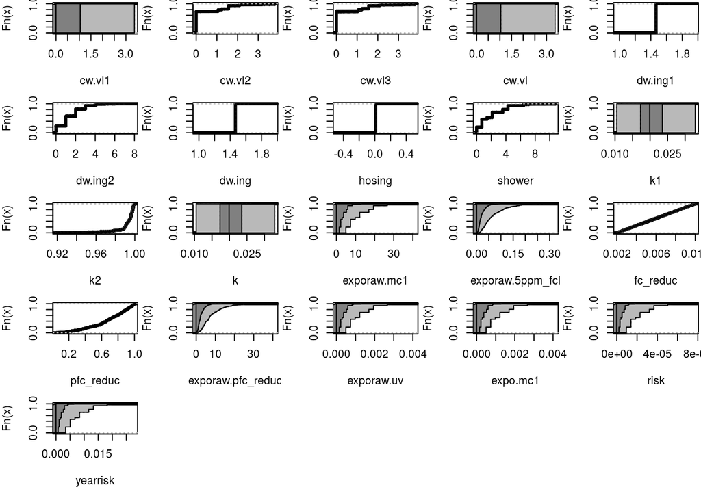

```r
# Plot the results.
plot(expo.ev1)
```

Report the mean and median of the DAILY risk probability means with a 95% confidence interval (CI95).

```r
mean.risk <- sapply(1:ndunc(), function(j) mean(expo.ev1$risk[, j, ]))
mean(mean.risk)
```

```
## [1] 3.402741e-06
```

```r
quantile(mean.risk, probs = seq(0, 1, 0.025))[c("2.5%", "50%", "97.5%")]
```

```
##         2.5%          50%        97.5%
## 0.000000e+00 0.000000e+00 2.236831e-05
```

Report the mean and median of the YEARLY risk probability means with a 95% confidence interval (CI95).

```r
mean.yearrisk <- sapply(1:ndunc(), function(j) mean(expo.ev1$yearrisk[, j, ]))
mean(mean.yearrisk)
```

```
## [1] 0.001236528
```

```r
quantile(mean.yearrisk, probs = seq(0, 1, 0.025))[c("2.5%", "25%", "50%", "75%", "97.5%")]
```

```
##        2.5%         25%         50%         75%       97.5%
## 0.000000000 0.000000000 0.000000000 0.001830530 0.008119335
```

Plot the empirical cumulative distribution function (ecdf) of the exposure model (`expo.mc1`) estimates.

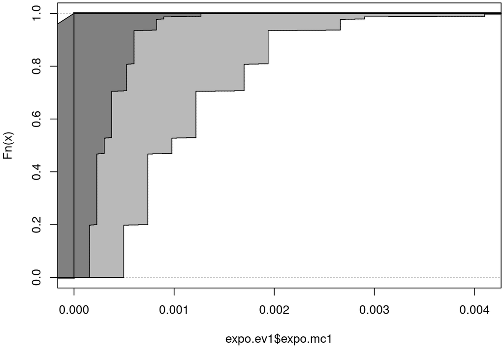

```r
# Generate an "ecdf" plot. This actually calls plot.mcnode().
plot(expo.ev1$expo.mc1)
```

Plot the empirical cumulative distribution function (ecdf) of the risk model (`risk`) estimates.

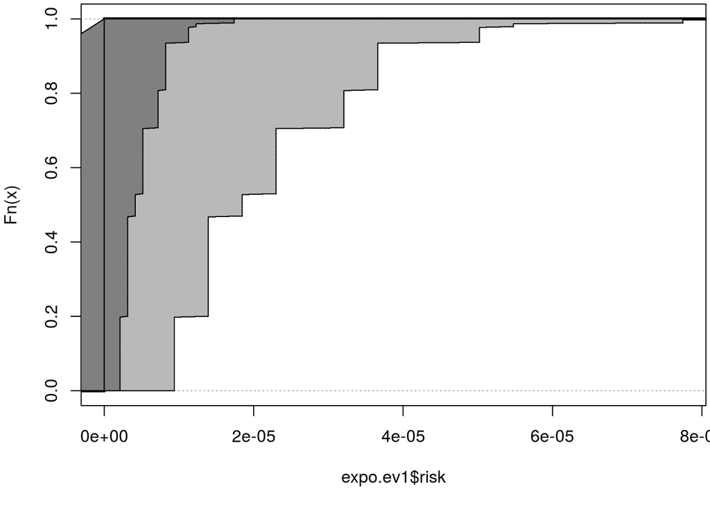

```r
# Generate an "ecdf" plot. This actually calls plot.mcnode().
plot(expo.ev1$risk)
```

So if we did this right, could the plot above can be correctly labeled as follows?

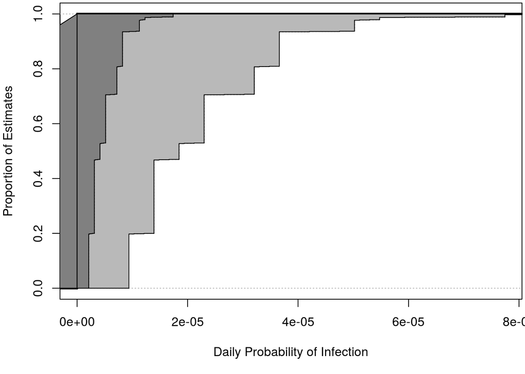

```r
# Generate an "ecdf" plot. This actually calls plot.mcnode().
plot(expo.ev1$risk, main = "", ylab = "Proportion of Estimates", xlab = "Daily Probability of Infection")
title("Daily Infec. Risk with Giardia by RCRW
in the USVI", cex.main = 1, font.main= 1, line = 7)
```

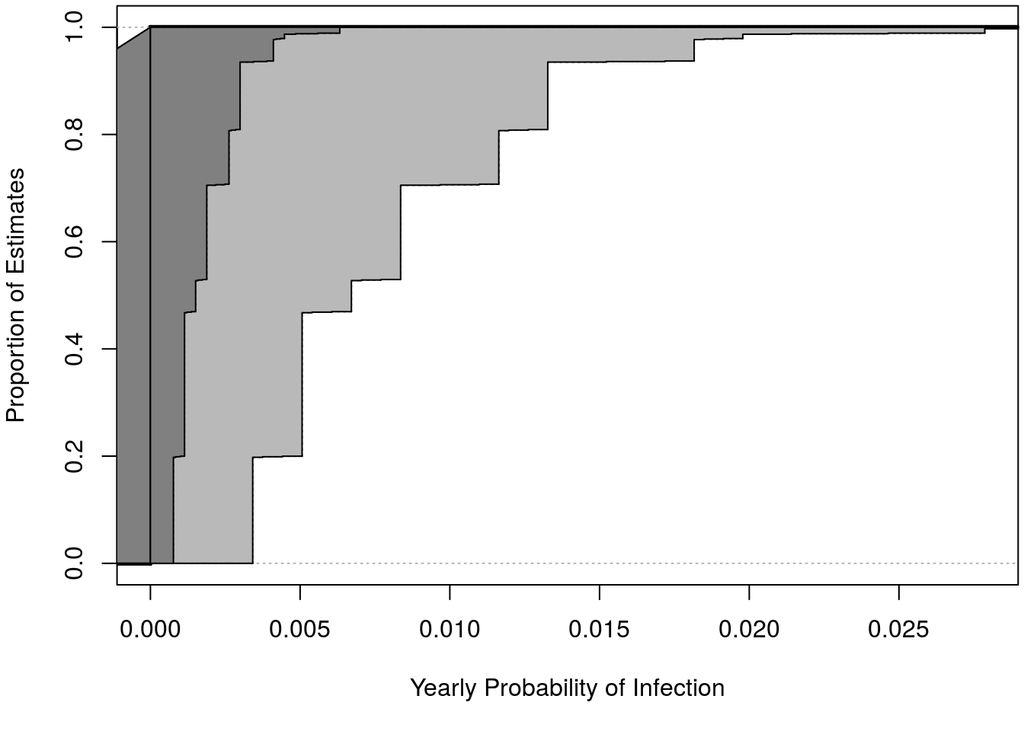

```r
# Generate an "ecdf" plot. This actually calls plot.mcnode().
plot(expo.ev1$yearrisk, main = "", ylab = "Proportion of Estimates", xlab = "Yearly Probability of Infection")
title("Yearly Infec. Risk with Giardia by RCRW
in the USVI", cex.main = 1, font.main= 1, line = 7)
```

Manually remake the graph, this time using yearrisk, which should just be another mcnode object with all values between 0 and 1:

The first one plots yearrisk without a log x scale:

```r
library(reshape)
```

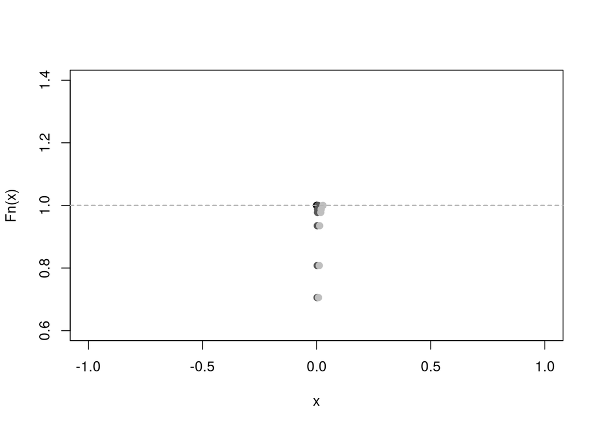

```r
library(ggplot2)
Risk.mat.1 <- expo.ev1$yearrisk[,,]
probs1 <- c(0.025, 0.25, 0.50, 0.75, 0.975)
quant1 <- as.data.frame(t(apply(Risk.mat.1, 1, quantile, probs = probs1)))
ecdfs1 <- sapply(names(quant1), function(q) ecdf(quant1[[q]]))
plot(ecdfs1[['50%']], main = '')
grays <- c('gray75', 'gray35', 'black', 'gray35', 'gray75')
lines <- mapply(function(e, g) lines(e, col = g), ecdfs1, grays)
```

Plotting yearrisk ECDF plot with ggplot2:

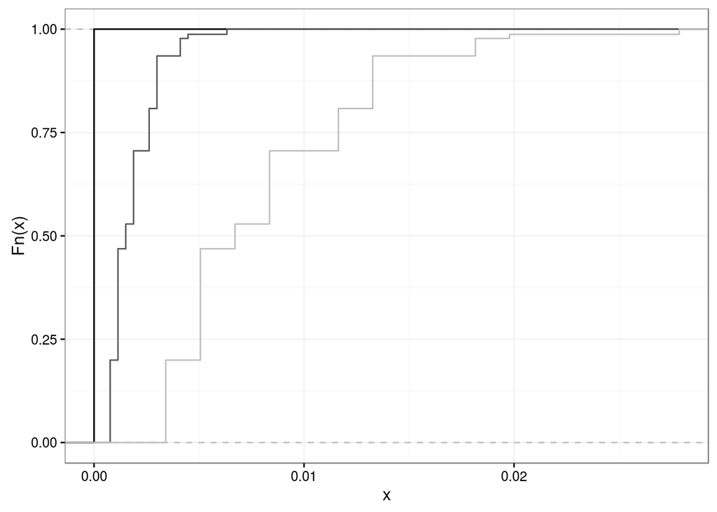

```r
quant.melt1 <- suppressMessages(melt(quant1))
names(quant.melt1) <- c('q', 'x')
grays <- c('gray75', 'gray35', 'black', 'gray35', 'gray75')
ggplot(quant.melt1, aes(x = x)) + theme_bw() + theme(legend.position = 'none') + geom_hline(yintercept = c(0, 1), linetype = "dashed", color = 'gray') + stat_ecdf(aes(group = q, color = q)) + xlab('x') + ylab('Fn(x)') + scale_colour_manual(values = grays)
```

Plot Version 2 with ggplot2, and a log-scale x axis:

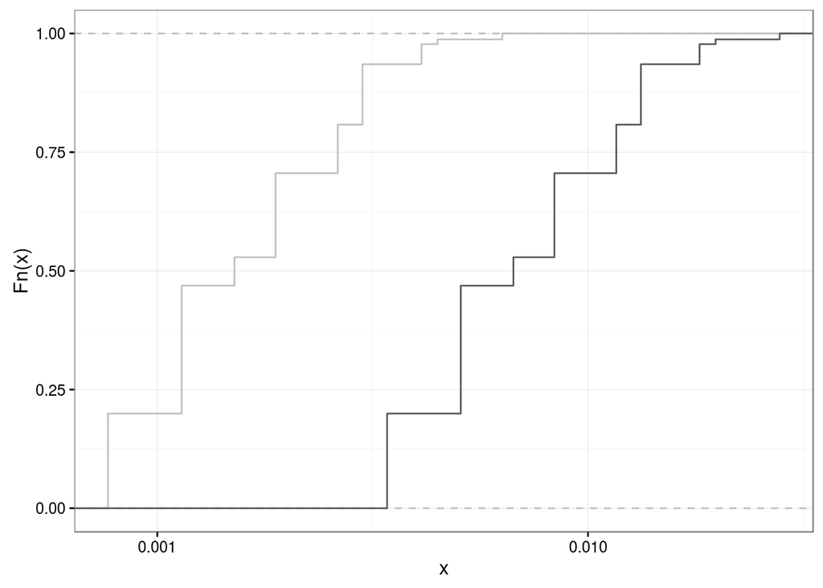

```r
quant.melt1 <- suppressMessages(melt(quant1))
names(quant.melt1) <- c('q', 'x')
grays <- c('gray75', 'gray35', 'black', 'gray35', 'gray75')
ggplot(quant.melt1, aes(x = x)) + theme_bw() + theme(legend.position = 'none') + geom_hline(yintercept = c(0, 1), linetype = "dashed", color = 'gray') + stat_ecdf(aes(group = q, color = q)) + xlab('x') + ylab('Fn(x)') + scale_colour_manual(values = grays) + scale_x_log10()
```